# CSE 5370: Course Timeslot and Student Assignment Project

# Part 1

**Name:** Victoria Vo  
**ID:** 46519204

# Introduction

**Summary:** This project looks at implementing an algorithm to solve the problem of assigning students to courses and finding timeslots for the courses being offered so that the students can attend the courses they wish to take.

**In this first part:**

- I created the raw data on course requests for the students
- Split the courses into different sections
- Developed a sequential adjacency list data structure for section conflicts based on the student course requests

# Implementation

Purpose:  
Determine which courses each student will take. The courses are numbered from 1 to C. The courses for each student will be determined based on a random number generator with different distributions. Part 1 will then split the courses into distinct sections and then determine which sections of which courses must be scheduled at a different time from each other to avoid conflicts in the students' schedules.

Take in these inputs:

- C = Number of courses being offered (MAX = 10,000)
- S = Number of students (MAX = 100,000)
- K = Number of courses per student. (MAX = C)
- SectionSize = the target size of a section
- SPLIT = BASIC | ADVANCED
- DIST = UNIFORM | 2-TIERED | 4-TIERED | NORMAL (my custom function)

Return the output:

- C = Number of courses being offered
- S = Number of students
- K = Number of courses per student
- SectionSize = the target size of a section
- SPLIT = BASIC | ADVANCED
- DIST = UNIFORM | 2-TIERED | 4-TIERED | NORMAL
- M = number of distinct pair-wise section conflicts
- T = total number of pair-wise section conflicts
- E[] = adjacency list of distinct section conflicts (length = 2M)
- P[] = Pointer for each section I, 1 <= I <= N denoting the starting point in E[] of the list of sections in conflict with section I. That is, the conflicts for section I are indicated in locations E[P[I]], E[P[I]+1], ..., E[P[I+1]-1].

### Imports for implementation

```python
%pylab inline
import numpy as np
from numpy import loadtxt
import random
import matplotlib.pyplot as plt
import collections
import itertools
import time as t
import collections
from collections import defaultdict
```

### Create raw data/test data and read it in

For the second part, I would like to move this within my main function. I would like to create a read function that takes in the raw file and initializes the variables within the main class. To get me started and for the purposes of this first part, I have my variables defined globally across this Jupyter Notebook and have an update function that takes any test file (I decided to continuously rewrite a single test file) and changes these global variables. I would then run my part 1 code with the new parameters.

#### Creating a file

```python
%%writefile project_test1.txt
3
10
2
3
BASIC
UNIFORM
```

```
Overwriting project_test1.txt
```

#### Global default variables

```python
C = 0
S = 0
K = 0
SectionSize = 0
SPLIT = ''
DIST = ''
selected_courses = [] #global variable for the purposes of graphing
```

#### Update Parameters Function

```python
#reads in test file and updates global parameters
def update_parameters(test_file):
    data = open(test_file, 'r')
    data = data.readlines()

    # will also do error checking for parameters here
    C = int(data[0][:-1])
    if ((C <= 0) or (C > 10000)): print ("ERROR: Maximum value of C is 10,000")

    S = int(data[1][:-1])
    if ((S <= 0) or (S > 100000)): print ("ERROR: Maximum value of S is 100,000")

    K = int(data[2][:-1])
    #if ((K <= 0) or (K > C)): print ("ERROR: You can't have more courses per student than courses available")

    SectionSize = int(data[3][:-1])
    SPLIT = data[4][:-1]
    DIST = data[5][:-1]

    # Checks if distribution is possible
    # The number of samples must not exceed the population range
    # (since only unique values can be taken)
    #if(((C*.25) < (K*.4)) and (DIST == "4-TIERED")):
        #print("ERROR: This distribution cannot be achieved for the given parameters.")
        #DIST = input("Try another distribution: ")

    selected_courses = [] #global variable for the purposes of graphing

    return C, S, K, SectionSize, SPLIT, DIST, selected_courses
```

### Course Assignment Function

#### Function Purpose:

Assign courses to students in a manner that satisfies the given specified distribution for the courses.

#### Distributions:

- Uniform Distribution:
  - Notes:

    ```
      All courses have equal probability. For each student, we'll want to extend the range of courses they
      can choose from to the entire course list and pick only k for each student.
    ```

- 2-Tiered Distribution:
  - Notes:

    ```
      The 2-tiered distribution assumes that the first 10% of courses have 50% of the probability distribution. The remaining 90% of courses have 50% of the probability distribution as well.
    ```

- 4-Tiered Distribution:
  - Notes:

    ```
      The 4-tiered distribution assumes
      - first 25% of courses have 40% probability
      - next 25% have 30% probability
      - next 25% has 20% probability
      - last 25% has 10% probability
    ```

- Normal Distribution:
  - Notes:

    ```
      Gaussian/Normal distribution:
      - 68% of the values lie within 1 standard deviation of the mean
      - 95% lie within 2 standard deviations
      - 99.7% lie within 3 standard deviations
      references: https://introcs.cs.princeton.edu/python/appendix_gaussian/
    ```

My shuffle method is O(n)

- Using len(list) is an O(1) operation
- The for loop is O(n) operation
- The variable assignment and swaps are O(1) operations

```python
# Shuffle function adapted from: https://cs.stackexchange.com/questions/47338/whats-a-uniform-shuffle
# This function will change the arrangement of the list, but not the elements
def shuffle(list):
    n = len(list) #number of items into the list
    for i in range(n-1):
        #pick a random index from the list
        j = random.randint(i, n-1)
        #swap the current item in the list with the item at the randomly selected index
        (list[i], list[j]) = (list[j], list[i])
```

My sample method is O(n)

- setting sample_range is O(n x (high-low))
- shuffle is O(n)
- setting the sample_list is O(n)

```python
def sample(low, high, size):
    sample_range = list(range(low, high))
    shuffle(sample_range)
    sample_list = sample_range[0:size]
    return sample_list
```

My sample w/o duplicates method is O(size * len(listobj)), which might be approximated to ~O(n^2)

- setting sample_range and sample_list is O(1)
- shuffle is O(len(listobj))
- the if statement and the while loop in the for loop uses a check that is an O(n) operation, so it is O(len(listobj))
- because of that, the entire for loop is O(size * len(listobj))

```python
def sample_wo_duplicates(listobj, size):
    sample_range = listobj
    sample_list = []
    shuffle(sample_range)
    for i in range(size):
        if(sample_range[i] not in sample_list):
            sample_list.append(sample_range[i])
        else:
            rand_index = random.randint(i, len(sample_range)-1)
            rand_item = (sample_range[rand_index])
            while (rand_item in sample_list):
                rand_index = random.randint(i, len(sample_range)-1)
                rand_item = (sample_range[rand_index])
            sample_list.append(rand_item)
    return sample_list
```

```python
def distribute_courses(dist, students, c, k):
    # Data structures (return variables) for these assignments:
    # student_enrollment -- type: dict, item = keypair : (key = each student : pair = courses student is taking)
    # course_enrollment -- type: dict,  item = (key = each course : pair = students in the course)
    # selected_courses -- type: list, item = tuple : (course number, # of students in course)

    student_enrollment, course_enrollment, selected_courses = ({}, {}, []) #initialize data structures

    if(dist == 'UNIFORM'):
        for student in students:
            course_selection = []

            # randomly pick k classes for each student
            # setting the population to the range(0,c) ensures an equal course seleciton probability
            course_selection = sample(0,c,k)

            # populate a dictionary of the students assigned to each course
            for course_num in course_selection:
                if(bool(course_enrollment.get(course_num)) == False):
                    course_enrollment[course_num] = [student]
                else:
                    course_enrollment[course_num].append(student)

            # populate a dictionary of the courses assigned to each student
            student_enrollment[student] = sorted(course_selection)

            # populate a list that keeps track of how many students are in each course
            for course in course_selection:
                selected_courses.append(course)
    if(dist == '2-TIERED'):
        #determine first 10% of courses
        first_10pct = round(c*.1)

        for student in students:
            course_selection, course_selection_first50, course_selection_last50 = ([], [], [])

            course_selection_first50 = list(range(0, first_10pct))
            shuffle(course_selection_first50)

            course_selection_last50 = list(range(first_10pct, c))
            shuffle(course_selection_last50)

            for picked_course in range(k):
                #Randomly select from one of the 2 lists created above
                #By using random.randint with 2 options, this means each option has a 50% chance
                #of getting selected since each integer created has an equal probability
                list_to_pick_from = random.randint(0,1)
                if (list_to_pick_from == 0):
                    # check if list is empty before trying to pick a course from it
                    # if list is empty, pick from other list
                    if(len(course_selection_first50) > 0):
                        course_selection.append(course_selection_first50.pop())
                    else:
                        course_selection.append(course_selection_last50.pop())
                else:
                    if(len(course_selection_last50) > 0):
                        course_selection.append(course_selection_last50.pop())
                    else:
                        course_selection.append(course_selection_first50.pop())

            for course_num in course_selection:
                if(bool(course_enrollment.get(course_num)) == False):
                    course_enrollment[course_num] = [student]
                else:
                    course_enrollment[course_num].append(student)

            student_enrollment[student] = course_selection


            for course in course_selection:
                selected_courses.append(course)

    if(dist == '4-TIERED'):
        weightedlist = []
        #determine indexes of each quartile
        first_quartile = round(c/4)
        second_quartile = first_quartile * 2
        third_quartile = first_quartile * 3
        last_quartile = c

        quartile1 = list(range(0, first_quartile)) #add 4 of these to list to simulate 40%
        quartile2 = list(range(first_quartile, second_quartile)) #add 3 of these to list to simulate 30%
        quartile3 = list(range(second_quartile, third_quartile)) #add 2 of these to list to simulate 20%
        quartile4 = list(range(third_quartile, last_quartile)) #add 1 of these to list to simulate 10%

        weightedlist= (quartile1 + quartile1 + quartile1 + quartile1 + quartile2 + quartile2 + quartile2
                    + quartile3 + quartile3 + quartile4)

        for student in students:
            course_selection = sample_wo_duplicates(weightedlist, k)

            for course_num in course_selection:
                if(bool(course_enrollment.get(course_num)) == False):
                    course_enrollment[course_num] = [student]
                else:
                    course_enrollment[course_num].append(student)

            student_enrollment[student] = sorted(course_selection)

            for course in course_selection:
                selected_courses.append(course)

    if(dist == 'NORMAL'):
        #get median/mean/mode (these should be equal) course number
        if((c%2) == 0):
            mu = round(c/2)
        else:
            mu = round(c/2) + 1


        #obtain sigma value (standard deviation)
        sigma = mu/3
        neg3_sigma = round(mu - sigma*3)
        neg2_sigma = round(mu - sigma*2)
        neg1_sigma = round(mu - sigma)
        pos1_sigma = round(mu + sigma)
        pos2_sigma = round(mu + sigma*2)
        pos3_sigma = round(mu + sigma*3)

        #sigma1 ~ 68%; sigma2 (neg and pos) ~ 13.5% * 2; sigma3 (neg and pos) ~ 2.5% * 2
        sigma1_selections = list(range(neg1_sigma,pos1_sigma))

        #combine the positive and negative parts
        sigma2neg_selections = list(range(neg2_sigma,neg1_sigma))
        sigma2pos_selections = list(range(pos1_sigma,pos2_sigma))
        #sigma2_selections = sigma2neg_selections + sigma2pos_selections

        #combine the positive and negative parts
        sigma3neg_selections = list(range(0,neg2_sigma))
        sigma3pos_selections = list(range(pos2_sigma,C))
        sigma3_selections = sigma3neg_selections + sigma3pos_selections

        weightedlist = []
        #Instead of the 21 list additions below, I could have also used 10 additions
        #where sigma1 was added 7 times, sigma2 added 2 times, and sigma3 added once
        #sigma 3 = 5%; sigma 2 = 27% ~ 6 * 5%; sigma 1 = 68% ~ 14 * 5%
        weightedlist = sigma3_selections
        for i in range(3):
            weightedlist += sigma2neg_selections
        for i in range(3):
            weightedlist += sigma2pos_selections
        for i in range(14):
            weightedlist += sigma1_selections

        for student in students:
            course_selection = sample_wo_duplicates(weightedlist, k)

            #create a dictionary of the students assigned to each course
            for course_num in course_selection:
                if(bool(course_enrollment.get(course_num)) == False):
                    course_enrollment[course_num] = [student]
                else:
                    course_enrollment[course_num].append(student)

            #assign the courses to each student
            #the lists contain the indices of the course names defined in the list, courses
            student_enrollment[student] = sorted(course_selection)
            for course in course_selection:
                selected_courses.append(course)

    return selected_courses, student_enrollment, course_enrollment
```

```python
def determine_courses(c, s, k, sectionsize, split, dist):
    # create list data structure for each student
    students = []
    for student_num in range(s):
        students.append(student_num)

    # based on the determined distribution, randomly assign courses to each student
    selected_courses, student_enrollment, course_enrollment = distribute_courses(dist, students, c, k)

    # convert the list into a counter which will show the course number and the number of students in each course
    selected_courses = sorted(collections.Counter(selected_courses).items())

    return selected_courses, student_enrollment, course_enrollment
```

### Section Split Function

This split should work to ensure both the minimum and maximum conditions are met. If the minimum capacity is not met in the final section split, you could get rid of the last section and distribute its students among the other sections without exceeding the maximum capacity.

```python
def section_split(s, c, sectionsize, split, course_selections, student_enrollment, course_enrollment):
    course_sections = {} # sections per course

    # student_section_schedule = courses that the student is taking with the section numbers
    # will be a dictionary of the courses a student is taking and the session number associated with it
    # ex: {student0 : { course0: section1, course19: section3, course3: section1}}
    student_section_schedule = {}

    minsize = round(2/3*sectionsize)
    maxsize = round(4/3*sectionsize)

    #split mainly if maximum section size is exceeded (4/3 * sectionsize)
    if (split == "BASIC"):
        #-----------Number of Sections Determination--------------------------------
        for course in course_selections: #c[0,1] = [course num, students in course]
            sections = 0 #number of sections for each course

            #check if you should have multiple sections
            if (course[1] <= maxsize):
                sections = 1
            else:
                if((course[1] % sectionsize) < minsize):
                    sections = int(floor(course[1]/sectionsize))
                else:
                    sections = int(course[1]/sectionsize) + 1

            course_sections[course[0]] = sections #save the number of sections to each course number

        #-----------Section Split Determination--------------------------------
        #Go through students in each course and assign them to a section
        for course, students in course_enrollment.items():
            # There aren't enough students in the course to create another section or
            # the calculation above determined there should only be one section
            # containing all students enrolled in the course
            if ((len(students) <= sectionsize) or (course_sections[course] == 1)):
                section_num = 0
                #go ahead and assign all students taking this course to section0
                for student in students:
                    #create section identifier with the course number followed by the section number
                    section_id = str(course) + '_' + str(section_num)

                    #populate the dictionary that tracks the student and the sections they're in
                    if(bool(student_section_schedule.get(student)) == False):
                        student_section_schedule[student] = [section_id]
                    else:
                        student_section_schedule[student].append(section_id)

            #----At this point splitting into multiple sections is required----
            # Note: If you create a new section only if you reach the maximum size,
            #       this doesn't guarantee that each section will meet the minimum size.
            #       This is why I proceed with the following method.
            #
            # Method:
                #1. Fill each section to 2/3*sectionsize
                #2. Then distribute remaining students until they're all distributed
            else:
                # list of students taking specific course
                students_list = students
                # predetermined list of the number of students that should be in each course
                num_of_sections = course_sections[course]
                # dictionary of the course sections and the students assigned to them
                section_assignments = {}

                # get optimal section size
                # This is the base amount to start assigning students to sections.
                # Get a chunk of students to be in the particular section, then get the remaining
                # students (fill_to) and go back and forth refilling each existing section.
                optimal_sectionsize = 0

                if (((len(students) % sectionsize) <= minsize) or
                    ((sectionsize * num_of_sections) > len(students))):
                    optimal_sectionsize = minsize
                    fill_to = maxsize - minsize
                else:
                    optimal_sectionsize = sectionsize
                    fill_to = maxsize - sectionsize

                #initial splitting
                for section in range(num_of_sections):
                    section_students = sample_wo_duplicates(students, optimal_sectionsize)
                    section_assignments[section] = section_students
                    for student in section_students:
                        students_list.remove(student)

                #split remaining students if any
                for section in range(num_of_sections):
                    while(len(students_list) > 0):
                        if(len(students) < fill_to):
                            fill_to = len(students)
                        #fill each existing session until maximum size reached
                        section_students = sample_wo_duplicates(students, fill_to)
                        section_assignments[section] += section_students
                        for student in section_students:
                            students_list.remove(student)

                #Now assign each student to a section
                for section, students in section_assignments.items():
                    section_id = str(course) + '_' + str(section)
                    #empty dictionary
                    for student in students:
                        if(bool(student_section_schedule.get(student)) == False):
                            student_section_schedule[student] = [section_id]
                        else:
                            student_section_schedule[student].append(section_id)

    else:
        print("Advanced Split") #Extra credit; chose not to implement for this part
        #find students with similar classes to each other and put them in a section together

    return student_section_schedule
```

### Course Section Conflicts Function

```python
def get_section_conflicts(s, course_sections, student_enrollment):
    conflicts = []

    #get pairwise combinations
    for i in range(s):
        #print(len(list(itertools.combinations(student_enrollment[i], 2))))# = K(K-1)/2 checked correctly!
        conflicts.extend(list(itertools.combinations(course_sections[i], 2)))
    T = len(conflicts)

    #removes duplicates / method should be O(M) space
    start = t.time()
    unique_conflicts = []
    unique_conflicts = list(set(conflicts[i] for i in range(len(conflicts))))
    M = len(unique_conflicts)
    end = t.time()
    remove_duplicates_runtime = end - start
    #prepare E[] and P[] arrays

    #will assign the conflicts between both elements in the pair
    #ex: (item1, item 2)
    #--> item1 will have item2 as a conflict
    #--> item2 will have item1 as a conflict
    E = defaultdict(list)
    for i in range(len(unique_conflicts)):
        if unique_conflicts[i][1] not in E[unique_conflicts[i][0]]:
            E[unique_conflicts[i][0]].append(unique_conflicts[i][1])
        if unique_conflicts[i][0] not in E[unique_conflicts[i][1]]:
            E[unique_conflicts[i][1]].append(unique_conflicts[i][0])

    conflict_adjacencies = dict(E)

    #reset E
    E = []
    P = []
    e_index = 0
    item_counter = 0
    num_items = len(conflict_adjacencies.items())

    #(course_conflicts[0,1]: [course, conflicting courses]
    for key, value in conflict_adjacencies.items():
        if (len(E) == 0):
            P.append(e_index)
        E += value
        e_index += len(E)
        item_counter += 1
        if(item_counter != num_items):
            P.append(len(E))

    return list(unique_conflicts), T, M, conflict_adjacencies, E, P, remove_duplicates_runtime
```

### Part 1 Program Function

```python
def part1(c, s, k, sectionsize, split, dist):
    course_selections, student_enrollment, course_enrollment = determine_courses(c, s, k, sectionsize, split, dist)
    course_sections = section_split(s, c, sectionsize, split, course_selections, student_enrollment, course_enrollment)

    #course-wise conflicts
    #course_conflicts, T, M, adjacency_list, E, P = get_conflicts(s, course_sections, student_enrollment)

    suppress_outputs = input("Suppress adjacency list outputs? Enter Y: ")

    #section-wise conflicts
    course_conflicts, T, M, adjacency_list, E, P, remove_duplicates_runtime = get_section_conflicts(s, course_sections, student_enrollment)

    print("OUTPUT:\n")
    print("Parameters: \n")
    print("C:", c)
    print("S:", s)
    print("K:", k)
    print("SectionSize:", sectionsize)
    print("SPLIT:", split)
    print("DIST:", dist)
    print("\nStudent Assignment Calculations:")
    print("T:", T)
    print("M:", M)
    if(suppress_outputs != "Y"):
        print("-------------------------------------")
        print("Adjacency_list", adjacency_list)
        print("-------------------------------------")
        print("E[]:", E)
        print("\nP[]:", P)
```

### Basic Tiny Test

```python
%%writefile project_test1.txt
10
20
3
5
BASIC
UNIFORM
```

```
Overwriting project_test1.txt
```

```python
C, S, K, SectionSize, SPLIT, DIST, selected_courses = update_parameters("project_test1.txt")
part1(C, S, K, SectionSize, SPLIT, DIST)
```

```
Suppress adjacency list outputs? Enter Y:
OUTPUT:

Parameters:

C: 10
S: 20
K: 3
SectionSize: 5
SPLIT: BASIC
DIST: UNIFORM

Student Assignment Calculations:
T: 60
M: 41
-------------------------------------
Adjacency_list {'5_1': ['9_0', '8_0', '1_0', '0_0'], '9_0': ['5_1', '0_0', '2_0', '3_0', '1_0', '7_0', '5_0', '6_0', '8_0'], '5_0': ['0_0', '7_0', '9_0', '8_1', '1_0', '2_0', '3_0', '8_0'], '0_0': ['5_0', '1_0', '9_0', '7_0', '6_0', '2_0', '5_1', '8_1', '4_0', '8_0'], '6_0': ['4_0', '0_0', '8_0', '2…
-------------------------------------
E[]: ['9_0', '8_0', '1_0', '0_0', '5_1', '0_0', '2_0', '3_0', '1_0', '7_0', '5_0', '6_0', '8_0', '0_0', '7_0', '9_0', '8_1', '1_0', '2_0', '3_0', '8_0', '5_0', '1_0', '9_0', '7_0', '6_0', '2_0', '5_1', '8_1', '4_0', '8_0', '4_0', '0_0', '8_0', '2_0', '9_0', '8_1', '6_0', '1_0', '8_1', '2_0', '0_0', …

P[]: [0, 4, 13, 21, 31, 37, 42, 51, 57, 65, 70, 78]
```

Awesome, this works! Now we'll test with some medium sets. I added a question whether to suppress outputs because as the parameters increase, the conflicts become difficult to look at.

### Medium Test

```python
%%writefile project_test1.txt
100
50
5
10
BASIC
UNIFORM
```

```
Overwriting project_test1.txt
```

```python
C, S, K, SectionSize, SPLIT, DIST, selected_courses = update_parameters("project_test1.txt")
part1(C, S, K, SectionSize, SPLIT, DIST)
```

```
Suppress adjacency list outputs? Enter Y: Y
OUTPUT:

Parameters:

C: 100
S: 50
K: 5
SectionSize: 10
SPLIT: BASIC
DIST: UNIFORM

Student Assignment Calculations:
T: 500
M: 477
```

```python
%%writefile project_test1.txt
100
50
5
10
BASIC
2-TIERED
```

```
Overwriting project_test1.txt
```

```python
C, S, K, SectionSize, SPLIT, DIST, selected_courses = update_parameters("project_test1.txt")
part1(C, S, K, SectionSize, SPLIT, DIST)
```

```
Suppress adjacency list outputs? Enter Y: Y
OUTPUT:

Parameters:

C: 100
S: 50
K: 5
SectionSize: 10
SPLIT: BASIC
DIST: 2-TIERED

Student Assignment Calculations:
T: 500
M: 378
```

```python
%%writefile project_test1.txt
100
50
5
10
BASIC
4-TIERED
```

```
Overwriting project_test1.txt
```

```python
C, S, K, SectionSize, SPLIT, DIST, selected_courses = update_parameters("project_test1.txt")
part1(C, S, K, SectionSize, SPLIT, DIST)
```

```
Suppress adjacency list outputs? Enter Y: Y
OUTPUT:

Parameters:

C: 100
S: 50
K: 5
SectionSize: 10
SPLIT: BASIC
DIST: 4-TIERED

Student Assignment Calculations:
T: 500
M: 469
```

```python
%%writefile project_test1.txt
100
50
5
10
BASIC
NORMAL
```

```
Overwriting project_test1.txt
```

```python
C, S, K, SectionSize, SPLIT, DIST, selected_courses = update_parameters("project_test1.txt")
part1(C, S, K, SectionSize, SPLIT, DIST)
```

```
Suppress adjacency list outputs? Enter Y: Y
OUTPUT:

Parameters:

C: 100
S: 50
K: 5
SectionSize: 10
SPLIT: BASIC
DIST: NORMAL

Student Assignment Calculations:
T: 500
M: 417
```

### Large Test

```python
%%writefile project_test1.txt
1000
5000
7
30
BASIC
UNIFORM
```

```
Overwriting project_test1.txt
```

```python
C, S, K, SectionSize, SPLIT, DIST, selected_courses = update_parameters("project_test1.txt")
part1(C, S, K, SectionSize, SPLIT, DIST)
```

```
Suppress adjacency list outputs? Enter Y: Y
OUTPUT:

Parameters:

C: 1000
S: 5000
K: 7
SectionSize: 30
SPLIT: BASIC
DIST: UNIFORM

Student Assignment Calculations:
T: 105000
M: 94814
```

```python
%%writefile project_test1.txt
1000
5000
7
30
BASIC
2-TIERED
```

```
Overwriting project_test1.txt
```

```python
C, S, K, SectionSize, SPLIT, DIST, selected_courses = update_parameters("project_test1.txt")
part1(C, S, K, SectionSize, SPLIT, DIST)
```

```
Suppress adjacency list outputs? Enter Y: Y
OUTPUT:

Parameters:

C: 1000
S: 5000
K: 7
SectionSize: 30
SPLIT: BASIC
DIST: 2-TIERED

Student Assignment Calculations:
T: 105000
M: 95843
```

```python
%%writefile project_test1.txt
1000
5000
7
30
BASIC
4-TIERED
```

```
Overwriting project_test1.txt
```

```python
C, S, K, SectionSize, SPLIT, DIST, selected_courses = update_parameters("project_test1.txt")
part1(C, S, K, SectionSize, SPLIT, DIST)
```

```
Suppress adjacency list outputs? Enter Y: Y
OUTPUT:

Parameters:

C: 1000
S: 5000
K: 7
SectionSize: 30
SPLIT: BASIC
DIST: 4-TIERED

Student Assignment Calculations:
T: 105000
M: 96429
```

```python
%%writefile project_test1.txt
1000
5000
7
30
BASIC
NORMAL
```

```
Overwriting project_test1.txt
```

```python
C, S, K, SectionSize, SPLIT, DIST, selected_courses = update_parameters("project_test1.txt")
part1(C, S, K, SectionSize, SPLIT, DIST)
```

```
Suppress adjacency list outputs? Enter Y: Y
OUTPUT:

Parameters:

C: 1000
S: 5000
K: 7
SectionSize: 30
SPLIT: BASIC
DIST: NORMAL

Student Assignment Calculations:
T: 105000
M: 96265
```

### Very Large Test

```python
%%writefile project_test1.txt
10000
10000
10
100
BASIC
UNIFORM
```

```
Overwriting project_test1.txt
```

```python
C, S, K, SectionSize, SPLIT, DIST, selected_courses = update_parameters("project_test1.txt")
part1(C, S, K, SectionSize, SPLIT, DIST)
```

```
Suppress adjacency list outputs? Enter Y: Y
OUTPUT:

Parameters:

C: 10000
S: 10000
K: 10
SectionSize: 100
SPLIT: BASIC
DIST: UNIFORM

Student Assignment Calculations:
T: 450000
M: 448039
```

```python
%%writefile project_test1.txt
10000
10000
10
100
BASIC
2-TIERED
```

```
Overwriting project_test1.txt
```

```python
C, S, K, SectionSize, SPLIT, DIST, selected_courses = update_parameters("project_test1.txt")
part1(C, S, K, SectionSize, SPLIT, DIST)
```

```
Suppress adjacency list outputs? Enter Y: Y
OUTPUT:

Parameters:

C: 10000
S: 10000
K: 10
SectionSize: 100
SPLIT: BASIC
DIST: 2-TIERED

Student Assignment Calculations:
T: 450000
M: 435256
```

```python
%%writefile project_test1.txt
10000
10000
10
100
BASIC
4-TIERED
```

```
Overwriting project_test1.txt
```

```python
C, S, K, SectionSize, SPLIT, DIST, selected_courses = update_parameters("project_test1.txt")
part1(C, S, K, SectionSize, SPLIT, DIST)
```

```
Suppress adjacency list outputs? Enter Y: Y
OUTPUT:

Parameters:

C: 10000
S: 10000
K: 10
SectionSize: 100
SPLIT: BASIC
DIST: 4-TIERED

Student Assignment Calculations:
T: 450000
M: 447161
```

```python
%%writefile project_test1.txt
10000
10000
10
100
BASIC
NORMAL
```

```
Overwriting project_test1.txt
```

```python
C, S, K, SectionSize, SPLIT, DIST, selected_courses = update_parameters("project_test1.txt")
part1(C, S, K, SectionSize, SPLIT, DIST)
```

```
Suppress adjacency list outputs? Enter Y: Y
OUTPUT:

Parameters:

C: 10000
S: 10000
K: 10
SectionSize: 100
SPLIT: BASIC
DIST: NORMAL

Student Assignment Calculations:
T: 450000
M: 442695
```

### Graphing the Course Assignment Distribution

#### Uniform Distribution Histogram

```python
%%writefile project_test1.txt
15
10000
3
2
BASIC
UNIFORM
```

```
Overwriting project_test1.txt
```

```python
C, S, K, SectionSize, SPLIT, DIST, selected_courses = update_parameters("project_test1.txt")
```

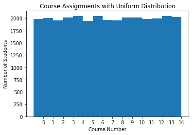

```python
selected_courses, course_assigments, course_enrollment = determine_courses(C, S, K, SectionSize, SPLIT, DIST)

labels, values = zip(*selected_courses)
indexes = np.arange(len(labels))
width = 1

plt.bar(indexes, values, width)
plt.xticks(indexes + width * 0.5, labels)
plt.xlabel("Course Number")
plt.ylabel("Number of Students")
plt.title("Course Assignments with Uniform Distribution")
plt.show()
```

#### 2-Tiered Distribution Histogram

```python
%%writefile project_test1.txt
15
10000
4
2
BASIC
2-TIERED
```

```
Overwriting project_test1.txt
```

```python
C, S, K, SectionSize, SPLIT, DIST, selected_courses = update_parameters("project_test1.txt")
```

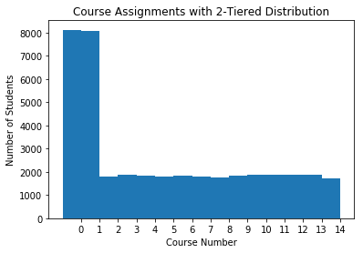

```python
selected_courses, student_enrollment, course_enrollment = determine_courses(C, S, K, SectionSize, SPLIT, DIST)

labels, values = zip(*selected_courses)
indexes = np.arange(len(labels))
width = 1

plt.bar(indexes, values, width)
plt.xticks(indexes + width * 0.5, labels)
plt.xlabel("Course Number")
plt.ylabel("Number of Students")
plt.title("Course Assignments with 2-Tiered Distribution")
plt.show()
```

#### 4-Tiered Distribution Histogram

```python
%%writefile project_test1.txt
100
10000
10
2
BASIC
4-TIERED
```

```
Overwriting project_test1.txt
```

```python
C, S, K, SectionSize, SPLIT, DIST, selected_courses = update_parameters("project_test1.txt")
```

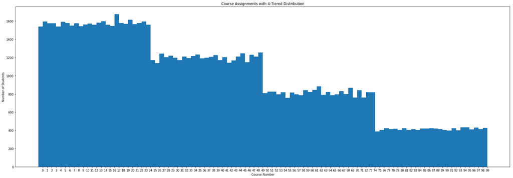

```python
selected_courses, student_enrollment, course_enrollment = determine_courses(C, S, K, SectionSize, SPLIT, DIST)

labels, values = zip(*selected_courses)
indexes = np.arange(len(labels))
width = 1

plt.figure(figsize=(30,10))
plt.bar(indexes, values, width)
plt.xticks(indexes + width * 0.5, labels)
plt.xlabel("Course Number")
plt.ylabel("Number of Students")
plt.title("Course Assignments with 4-Tiered Distribution")
plt.show()
```

#### Normal (My Custom) Distribution Histogram

```python
%%writefile project_test1.txt
550
1000
120
2
BASIC
NORMAL
```

```
Overwriting project_test1.txt
```

```python
C, S, K, SectionSize, SPLIT, DIST, selected_courses = update_parameters("project_test1.txt")
```

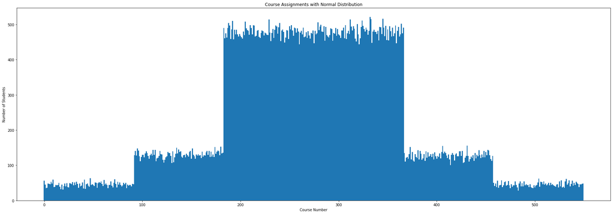

```python
selected_courses, student_enrollment, course_enrollment = determine_courses(C, S, K, SectionSize, SPLIT, DIST)

labels, values = zip(*selected_courses)
indexes = np.arange(len(labels))
width = 1

plt.figure(figsize=(30,10))
plt.bar(indexes, values, width)
#plt.xticks(indexes + width * 0.5, labels)
plt.xlabel("Course Number")
plt.ylabel("Number of Students")
plt.title("Course Assignments with Normal Distribution")
plt.show()
```

### Timing my function

```python
# will return execution times in seconds
def part1_timing(c, s, k, sectionsize, split, dist):
    start = t.time()
    course_selections, student_enrollment, course_enrollment = determine_courses(c, s, k, sectionsize, split, dist)
    end = t.time()

    determine_courses_runtime = end - start

    start = t.time()
    course_sections = section_split(s, c, sectionsize, split, course_selections, student_enrollment, course_enrollment)
    end = t.time()

    section_split_runtime = end - start

    #section-wise conflicts
    course_conflicts, T, M, adjacency_list, E, P, remove_duplicates_runtime = get_section_conflicts(s, course_sections, student_enrollment)


    print("Course Assignment Runtime:", determine_courses_runtime)
    print("Section Split Runtime:", section_split_runtime)
    print("Remove Duplicates Runtime: ", remove_duplicates_runtime)
```

### Get runtime examples to show the asymptotic bounds

```python
%%writefile project_test1.txt
100
50
5
10
BASIC
UNIFORM
```

```
Overwriting project_test1.txt
```

```python
C, S, K, SectionSize, SPLIT, DIST, selected_courses = update_parameters("project_test1.txt")
part1_timing(C, S, K, SectionSize, SPLIT, DIST)
```

```
Course Assignment Runtime: 0.008956193923950195
Section Split Runtime: 0.0003838539123535156
Remove Duplicates Runtime:  0.0001010894775390625
```

```python
%%writefile project_test1.txt
100
50
5
10
BASIC
2-TIERED
```

```
Overwriting project_test1.txt
```

```python
C, S, K, SectionSize, SPLIT, DIST, selected_courses = update_parameters("project_test1.txt")
part1_timing(C, S, K, SectionSize, SPLIT, DIST)
```

```
Course Assignment Runtime: 0.008759021759033203
Section Split Runtime: 0.0003228187561035156
Remove Duplicates Runtime:  9.894371032714844e-05
```

```python
%%writefile project_test1.txt
100
50
5
10
BASIC
4-TIERED
```

```
Overwriting project_test1.txt
```

```python
C, S, K, SectionSize, SPLIT, DIST, selected_courses = update_parameters("project_test1.txt")
part1_timing(C, S, K, SectionSize, SPLIT, DIST)
```

```
Course Assignment Runtime: 0.018108129501342773
Section Split Runtime: 0.00025200843811035156
Remove Duplicates Runtime:  8.7738037109375e-05
```

```python
%%writefile project_test1.txt
100
50
5
10
BASIC
NORMAL
```

```
Overwriting project_test1.txt
```

```python
C, S, K, SectionSize, SPLIT, DIST, selected_courses = update_parameters("project_test1.txt")
part1_timing(C, S, K, SectionSize, SPLIT, DIST)
```

```
Course Assignment Runtime: 0.04814004898071289
Section Split Runtime: 0.0002491474151611328
Remove Duplicates Runtime:  8.821487426757812e-05
```

```python
%%writefile project_test1.txt
1000
5000
10
30
BASIC
UNIFORM
```

```
Overwriting project_test1.txt
```

```python
C, S, K, SectionSize, SPLIT, DIST, selected_courses = update_parameters("project_test1.txt")
part1_timing(C, S, K, SectionSize, SPLIT, DIST)
```

```
Course Assignment Runtime: 7.812812089920044
Section Split Runtime: 0.18406987190246582
Remove Duplicates Runtime:  0.06772208213806152
```

```python
%%writefile project_test1.txt
1000
5000
10
30
BASIC
2-TIERED
```

```
Overwriting project_test1.txt
```

```python
C, S, K, SectionSize, SPLIT, DIST, selected_courses = update_parameters("project_test1.txt")
part1_timing(C, S, K, SectionSize, SPLIT, DIST)
```

```
Course Assignment Runtime: 7.944094896316528
Section Split Runtime: 0.29233694076538086
Remove Duplicates Runtime:  0.07361626625061035
```

```python
%%writefile project_test1.txt
1000
5000
10
30
BASIC
4-TIERED
```

```
Overwriting project_test1.txt
```

```python
C, S, K, SectionSize, SPLIT, DIST, selected_courses = update_parameters("project_test1.txt")
part1_timing(C, S, K, SectionSize, SPLIT, DIST)
```

```
Course Assignment Runtime: 19.83097004890442
Section Split Runtime: 0.16064190864562988
Remove Duplicates Runtime:  0.06158328056335449
```

```python
%%writefile project_test1.txt
1000
5000
10
30
BASIC
NORMAL
```

```
Overwriting project_test1.txt
```

```python
C, S, K, SectionSize, SPLIT, DIST, selected_courses = update_parameters("project_test1.txt")
part1_timing(C, S, K, SectionSize, SPLIT, DIST)
```

```
Course Assignment Runtime: 47.734002113342285
Section Split Runtime: 0.25377488136291504
Remove Duplicates Runtime:  0.07041001319885254
```

```python
%%writefile project_test1.txt
10000
10000
10
100
BASIC
UNIFORM
```

```
Overwriting project_test1.txt
```

```python
C, S, K, SectionSize, SPLIT, DIST, selected_courses = update_parameters("project_test1.txt")
part1_timing(C, S, K, SectionSize, SPLIT, DIST)
```

```
Course Assignment Runtime: 170.82645511627197
Section Split Runtime: 0.11867904663085938
Remove Duplicates Runtime:  0.15978407859802246
```

```python
%%writefile project_test1.txt
10000
10000
10
100
BASIC
2-TIERED
```

```
Overwriting project_test1.txt
```

```python
C, S, K, SectionSize, SPLIT, DIST, selected_courses = update_parameters("project_test1.txt")
part1_timing(C, S, K, SectionSize, SPLIT, DIST)
```

```
Course Assignment Runtime: 147.43513298034668
Section Split Runtime: 0.09339404106140137
Remove Duplicates Runtime:  0.13679099082946777
```

```python
%%writefile project_test1.txt
10000
10000
10
100
BASIC
4-TIERED
```

```
Overwriting project_test1.txt
```

```python
C, S, K, SectionSize, SPLIT, DIST, selected_courses = update_parameters("project_test1.txt")
part1_timing(C, S, K, SectionSize, SPLIT, DIST)
```

```
Course Assignment Runtime: 360.93773102760315
Section Split Runtime: 0.08785319328308105
Remove Duplicates Runtime:  0.13065814971923828
```

```python
%%writefile project_test1.txt
10000
10000
10
100
BASIC
NORMAL
```

```
Overwriting project_test1.txt
```

```python
C, S, K, SectionSize, SPLIT, DIST, selected_courses = update_parameters("project_test1.txt")
part1_timing(C, S, K, SectionSize, SPLIT, DIST)
```

```
Course Assignment Runtime: 902.530394077301
Section Split Runtime: 0.09146595001220703
Remove Duplicates Runtime:  0.1290576457977295
```

```python
%%writefile project_test1.txt
10000
20000
10
150
BASIC
UNIFORM
```

```
Overwriting project_test1.txt
```

```python
C, S, K, SectionSize, SPLIT, DIST, selected_courses = update_parameters("project_test1.txt")
part1_timing(C, S, K, SectionSize, SPLIT, DIST)
```

```
Course Assignment Runtime: 290.15584206581116
Section Split Runtime: 0.2241978645324707
Remove Duplicates Runtime:  0.28957080841064453
```

```python
%%writefile project_test1.txt
10000
20000
10
150
BASIC
2-TIERED
```

```
Overwriting project_test1.txt
```

```python
C, S, K, SectionSize, SPLIT, DIST, selected_courses = update_parameters("project_test1.txt")
part1_timing(C, S, K, SectionSize, SPLIT, DIST)
```

```
Course Assignment Runtime: 288.74087715148926
Section Split Runtime: 0.18125104904174805
Remove Duplicates Runtime:  0.2888917922973633
```

```python
%%writefile project_test1.txt
10000
20000
10
150
BASIC
4-TIERED
```

```
Overwriting project_test1.txt
```

```python
C, S, K, SectionSize, SPLIT, DIST, selected_courses = update_parameters("project_test1.txt")
part1_timing(C, S, K, SectionSize, SPLIT, DIST)
```

```
Course Assignment Runtime: 839.9693911075592
Section Split Runtime: 0.17865276336669922
Remove Duplicates Runtime:  0.3064250946044922
```

```python
%%writefile project_test1.txt
10000
20000
10
150
BASIC
NORMAL
```

```
Overwriting project_test1.txt
```

```python
C, S, K, SectionSize, SPLIT, DIST, selected_courses = update_parameters("project_test1.txt")
part1_timing(C, S, K, SectionSize, SPLIT, DIST)
```

```
Course Assignment Runtime: 1981.4264299869537
Section Split Runtime: 0.21297407150268555
Remove Duplicates Runtime:  0.2966909408569336
```

# CSE 5370: Course Timeslot and Student Assignment Project

# Part 2

# Introduction

**Summary:** This project looks at implementing an algorithm to solve the problem of assigning students to courses and finding timeslots for the courses being offered so that the students can attend the courses they wish to take. In this second part, I create 3 different methods of coloring a graph. Vertices of different colors will be course-sections that conflict with each other.

# Implementation

Purpose:  
Use three different methods for ordering the vertices in the graph: Smallest Last Vertex Ordering and 2 other methods of your choice. Then assign a color (scheduling time) to each vertex in the order determined so that it doesn't conflict with the other vertices already colored. Then compare the different ordering methodologies based on the following criteria: asymptotic running time, asymptotic space requirement, total number of colors needed, and a report on any other interesting metric.

Take in these inputs:

- C = Number of courses being offered
- S = Number of students
- K = Number of courses per student
- SectionSize = the target size of a section
- SPLIT = BASIC | ADVANCED
- DIST = UNIFORM | 2-TIERED | 4-TIERED | NORMAL
- M = number of distinct pair-wise section conflicts
- T = total number of pair-wise section conflicts
- E[] = adjacency list of distinct section conflicts (length = 2M)
- P[] = Pointer for each section I, 1 <= I <= N denoting the starting point in E[] of the list of sections in conflict with section I. That is, the conflicts for section I are indicated in locations E[P[I]], E[P[I]+1], ..., E[P[I+1]-1].

Return the output: Input parameters except E[] and P[]

- C = Number of courses being offered
- S = Number of students
- K = Number of courses per student
- SectionSize = the target size of a section
- SPLIT = BASIC | ADVANCED
- DIST = UNIFORM | 2-TIERED | 4-TIERED | NORMAL
- For each vertex (session) the color, original degree, (and degree when deleted for the smallest last ordering). These should be printed in the order colored.
- Total number of colors used
- The average original degree
- Maximum "degree when deleted" value for the smallest last ordering, and the size of the terminal clique for the smallest last ordering
- Additional summary data

### Imports for implementation

```python
from networkx import *
from platform import python_version
import networkx as nx
print ("NetworkX version:", networkx.__version__)
print ("Matplotlib version:", matplotlib.__version__)
print("Python version:", python_version())
```

```
NetworkX version: 2.3
Matplotlib version: 3.0.2
Python version: 3.6.8
```

NetworkX Documentation: https://networkx.github.io/documentation/stable/index.html

### Part 1 Program Function w/ Return Values

```python
def part1_return(c, s, k, sectionsize, split, dist):
    course_selections, student_enrollment, course_enrollment = determine_courses(c, s, k, sectionsize, split, dist)
    course_sections = section_split(s, c, sectionsize, split, course_selections, student_enrollment, course_enrollment)

    suppress_all_outputs = input("Suppress all outputs? Enter Y: ")
    suppress_outputs = "Y"
    if(suppress_all_outputs != "Y"):
        suppress_outputs = input("Suppress adjacency list outputs? Enter Y: ")

    #section-wise conflicts
    course_conflicts, T, M, adjacency_list, E, P, remove_duplicates_runtime = get_section_conflicts(s, course_sections, student_enrollment)
    if(suppress_all_outputs != "Y"):
        print("-----------------------------------------------------------------------")
        print("-----------------------------------------------------------------------")
        print("OUTPUT:\n")
        print("Parameters: \n")
        print("C:", c)
        print("S:", s)
        print("K:", k)
        print("SectionSize:", sectionsize)
        print("SPLIT:", split)
        print("DIST:", dist)
        print("\nStudent Assignment Calculations:")
        print("T:", T)
        print("M:", M)
    if((suppress_outputs != "Y")):
        print("-------------------------------------")
        print("Adjacency_list", adjacency_list)
        print("-------------------------------------")
        print("E[]:", E)
        print("\nP[]:", P)

    return c, s, k, sectionsize, split, dist, T, M, E, P, adjacency_list
```

### Graph Functions

#### Vertex Data Structure

A vertex (class session) will store 4 fields of data.

- Field 1 : session number
- Field 2 : P(I) = pointer to edge list
- Field 3 : current degree, -1 when deleted, color value
- Field 4 : pointers for doubly-linked list of vertices of same current degree, pointer for order deleted list

I'm going to make each field like a key for the above values. For a field with multiple values, the values will be stored to a list.

```python
class vertex:
    all_vertices = defaultdict(list)
    def __init__(self, sessionNumber="", currentDegree=0, color="none", color_num=0):
        self.session = sessionNumber
        self.degree = currentDegree
        self.color = color
        self.color_num = color_num
        self.dwd = -1
        vertex.all_vertices[self.session].append(self)
    def getColor(self):
        return self.color
    def setColor(self, color):
        self.color = color
    def getColorNum(self):
        return self.color_num
    def setColorNum(self, color_num):
        self.color_num = color_num
    def getDegree(self):
        return self.degree
    def setDWD(self, dwd):
        self.dwd = dwd
    def printVertex(self):
        print("vertexNo",self.session)
        print("degree",self.degree)
        print("color hex: %s number: %s" % (self.color, self.color_num))
    def printLastVertex(self):
        print("vertexNo",self.session)
        print("original degree",self.degree)
        print("degree when deleted",self.dwd)
        print("color hex: %s number: %s" % (self.color, self.color_num))
    @classmethod
    def findByVertexNo(cls, vtx):
        return vertex.all_vertices[vtx][0]
```

- #### Get Degrees of Vertices

```python
#Will take a graph and return the degree of a particular vertex or vertices
#Returned graph will be in the form of { session : degree }
def getDegree(graph, vertices):
    vertexDegrees = defaultdict(list)

    for vertex in vertices:
        degree = len(graph[vertex])
        vertexDegrees[vertex] = degree

    return vertexDegrees
```

- #### Get Vertices that Share the Same Degree

```python
def getSameDegree(graph):
    x = getDegree(graph,list(random_graph.keys()))
    #sort vertexDegrees in ascending order
    #create a new graph by degree
    sameDegree = {}
    checkedDegrees = []

    #session and the degree of the vertex
    sorted_x = sorted(x.items(), key=operator.itemgetter(1))

    vertexColors = {}
    for pair in sorted_x:
        degree = pair[1]
        vertex = pair[0]
        if(len(sameDegree) == 0):
            sameDegree[degree] = [vertex]
            checkedDegrees.append(degree)
        else:
            if(degree == checkedDegrees[len(checkedDegrees)-1]):
                sameDegree[degree].append(vertex)
            else:
                sameDegree[degree] = [vertex]
                checkedDegrees.append(degree)

    return sameDegree
```

```python
def getAvgDegree(adjacencies):
    degreeGraph = getDegree(adjacencies, list(adjacencies.keys()))
    degree_sum = 0
    for session, degree in degreeGraph.items():
        degree_sum += degree
    avg_degree = degree_sum / len(degreeGraph)

    return avg_degree
```

- #### Get Colors of Vertices

```python
import operator
from collections import OrderedDict
#color the vertices by order given by graph
def colorGraph(graph):
    vertexColors = {}
    adjacencyColors = {}

    #Create a random color (https://stackoverflow.com/questions/16819222/how-to-return-dictionary-keys-as-a-list-in-python)
    #initialize color array with one color
    r = lambda: random.randint(0,255)
    hexcode = ('#%02X%02X%02X' % (r(),r(),r()))
    usedColors=[hexcode]

    #check if color matches colors of the adjacent vertices
    for vtx, adjacencies in graph.items():

        #vertex isn't connected to any other vertex
        if(len(adjacencies) == 0):
            vertexColors[vtx] = usedColors[0]
            vertex.findByVertexNo(vtx).setColor(usedColors[0])
            vertex.findByVertexNo(vtx).setColorNum(1)

        #vertex has at least one neighbor and the nodes must be different colors
        else:
            adjacent_colors = []
            #look for all set colors (values that aren't "none")
            #vertex can't be these colors
            for a in adjacencies:
                vertex_color = vertex.findByVertexNo(a).getColor()
                if(vertex_color != ""):
                    adjacent_colors.append(vertex_color)
            uc_num = 1
            for uc in usedColors:
                #you find a color that isn't being used in adjacent vertices and can use it
                if (uc not in adjacent_colors):
                    vertexColors[vtx] = uc
                    vertex.findByVertexNo(vtx).setColor(uc)
                    vertex.findByVertexNo(vtx).setColorNum(uc_num)
                    break
                #you went through all available colors and now must create a new color
                if(uc == usedColors[len(usedColors)-1]):
                    r = lambda: random.randint(0,255)
                    #make sure to get a unique color that hasn't been used before
                    while(r in usedColors):
                        r = lambda: random.randint(0,255)
                    hexcode = ('#%02X%02X%02X' % (r(),r(),r()))
                    usedColors.append(hexcode)
                    vertexColors[vtx] = hexcode
                    vertex.findByVertexNo(vtx).setColor(hexcode)
                    vertex.findByVertexNo(vtx).setColorNum(len(usedColors))
                    break

                uc_num += 1
    colors = []
    for color_assignment in vertexColors.items():
        colors.append(color_assignment[1])

    totalColors = len(usedColors)


    return totalColors, colors, usedColors
```

- #### Get Terminal Clique Size

```python
def getTerminalClique(vstack, dwdlist):
    #go through dwdlist from the end to the front and look for the
    #increasing pattern
    clique_size = 0
    tclique = []
    for idx in range(len(dwdlist)-1):
        if ((dwdlist[idx] + 1) == dwdlist[idx+1]):
            clique_size += 1
            tclique.append(vstack[idx])
        else:
            clique_size += 1
            tclique.append(vstack[idx])
            break

    print("Terminal Clique", tclique)
    return (clique_size)
```

### Vertices Ordering Method 1: Smallest Last Vertex Ordering

1. Pick vertex of minium degree
2. Push on stack
3. Remove from graph
4. Repeat until done
5. Pop from stack and color

To find the terminal clique, I thought you might have to check through all the adjacencies of the vertices to be deleted, ensure they were all equal degrees and search for a decreasing sequence where the next list of adjacencies for the next vertex were equal and a degree less from the last vertex. However, I found a much easier way to check for this pattern, which is looking at the vertex at the end(the one that will be deleted); if the degree sequence of the vertices being deleted starts going down incrementally to 0, this is the terminal clique.

```python
%%time
#will get time of entire function, including time to produce outputs

def smallestLastVertex(c, s, k, sectionsize, split, dist, m, t, e, p, adjacencies):
    start = myTime.time()
    vertexStack = []
    degreeGraph2 = {}
    G = defaultdict(list)
    vertexDSStack = [] #added
    dwd = [] #added (degrees when deleted)

    #get the degrees for each vertex
    degreeGraph = getDegree(adjacencies, list(adjacencies.keys()))
    x=degreeGraph
    degreeGraph = sorted(x.items(), key=operator.itemgetter(1), reverse=True)
    #----------If you need to convert the ordered dict back into a dict----
    for pair in degreeGraph:
        degreeGraph2[pair[0]] = pair[1]
    #----------If you need to convert the ordered dict back into a dict----

    for v in range(len(degreeGraph2)):
        minVertex = degreeGraph[len(degreeGraph)-1][0]
        dwd.append(degreeGraph[len(degreeGraph)-1][1]) # added
        del degreeGraph[len(degreeGraph)-1]
        vertexStack.append(minVertex)
        #update the degrees of adjacent vertices
        minVertexList = adjacencies[minVertex]

        for vtx in minVertexList:
        #decrease the degree of these adjacent vertices
            if (vtx not in vertexStack):
                degreeGraph2[vtx] = degreeGraph2[vtx] - 1
        del degreeGraph2[minVertex]

        degreeGraph = sorted(degreeGraph2.items(), key=operator.itemgetter(1), reverse=True)

    vertexStack.reverse()
    dwd.reverse() #added

    dwd_index = 0 # added
    for v in vertexStack:
        v_adjacencies = adjacencies[v]
        G[v] = v_adjacencies
        vertexDSStack.append(vertex(v, getDegree(adjacencies, [v])[v], "", 0)) #added
        vertex.findByVertexNo(v).setDWD(dwd[dwd_index])#added
        dwd_index += 1 #added
    end = myTime.time()
    ordering_time = end - start

    print("\nSmallest Last Vertex")

    #Color the graph
    start = myTime.time()
    totalColors, vertexColors, usedColors = colorGraph(G) #added
    end = myTime.time()
    coloring_time = end - start

    #Outputs

    if(OUTPUT2_VERBOSE == True):
        for v in vertexStack:
            vertex.findByVertexNo(v).printLastVertex()

    print("\n")
    print("Total number of colors used:", totalColors)
    print("Rounded Average Degree:", round(getAvgDegree(adjacencies)))
    print("Maximum Average Degree When Deleted:", max(dwd))
    print("Terminal Clique Size:", getTerminalClique(vertexStack, dwd))

    if(OUTPUT2_EXTRA == True):
        plotDegreeOrder(vertexDSStack)
        colorCount(vertexColors, usedColors)
    if(OUTPUT2_GRAPH == True):
        drawGraph(G, True, vertexColors)

    return G, ordering_time, coloring_time
```

```
CPU times: user 8 µs, sys: 1e+03 ns, total: 9 µs
Wall time: 12.6 µs
```

### Vertices Ordering Method 2: Random Vertex Ordering

```python
%%time

def randomVertex(c, s, k, sectionsize, split, dist, m, t, e, p, adjacencies):
    start = myTime.time()
    print("\nRandom Vertex")
    # You really only need the adjacency graph, e
    # 1.1 initialize the vertex list
    V = []
    # 1.2 initialize the graph that will be returned
    G = defaultdict(list)
    # 2. initialize one list to keep track of vertex ordering
    #    and another list of vertices with the session and the color and degree of it
    vertexStack = []
    vertexDSStack = []

    # 3. add each session from the adjacency graph as a vertex to the vertex list
    for session, conflicting_sessions in adjacencies.items():
        V.append(session)

    # 4. for each vertex in the list,
    #    - 4.1 randomly pick a vertex from the vertex list
    #    - 4.2 get the adjacent vertices
    #    - 4.3 assign the adjacent vertices to the selected vertex and make this an item of the graph
    #    - 4.4 remove the vertex from the vertex list
    while len(V) > 0:
        randomIndex = random.randint(0, len(V)-1)
        vpick = V[randomIndex]
        vpick_adjacencies = adjacencies[vpick]
        G[vpick] = vpick_adjacencies
        vertexStack.append(vpick)
        vertexDSStack.append(vertex(vpick, getDegree(adjacencies, [vpick])[vpick], "", 0))
        V.remove(vpick)
    end = myTime.time()
    ordering_time = end - start

    start = myTime.time()
    # 5. Color the graph
    totalColors, vertexColors, usedColors = colorGraph(G)
    end = myTime.time()
    coloring_time = end - start

    # 6. Print the output data:
    #    - Inputs except for e and p
    #    - For each vertex, the color and degree (printed in the order that the vertices are colored)
    #    - Total number of colors used
    #    - The average degree
    #    - Graph indicating the degree on the vertical axes and the order colored on the x-axis
    #    - Additional Summary Data

    if(OUTPUT2_VERBOSE == True):
        for v in vertexStack:
            vertex.findByVertexNo(v).printVertex()

    print("\n")
    print("Total number of colors used:", totalColors)
    print("Rounded Average Degree:", round(getAvgDegree(adjacencies)))
    if(OUTPUT2_EXTRA == True):
        plotDegreeOrder(vertexDSStack)
        colorCount(vertexColors, usedColors)
    if(OUTPUT2_GRAPH == True):
        drawGraph(G, True, vertexColors)

    # 7. return
    return G, ordering_time, coloring_time
```

```
CPU times: user 8 µs, sys: 1e+03 ns, total: 9 µs
Wall time: 12.2 µs
```

### Vertices Ordering Method 3: Largest Last Vertex

```python
%%time

def largestLastVertex(c, s, k, sectionsize, split, dist, m, t, e, p, adjacencies):
    start = myTime.time()
    vertexStack = []
    degreeGraph2 = {}
    G = defaultdict(list)
    vertexDSStack = [] #added
    dwd = [] #added (degrees when deleted)

    #get the degrees for each vertex
    degreeGraph = getDegree(adjacencies, list(adjacencies.keys()))
    x=degreeGraph
    degreeGraph = sorted(x.items(), key=operator.itemgetter(1), reverse=False)
    #----------If you need to convert the ordered dict back into a dict----
    for pair in degreeGraph:
        degreeGraph2[pair[0]] = pair[1]
    #----------If you need to convert the ordered dict back into a dict----

    for v in range(len(degreeGraph2)):
        maxVertex = degreeGraph[len(degreeGraph)-1][0]
        dwd.append(degreeGraph[len(degreeGraph)-1][1]) # added
        del degreeGraph[len(degreeGraph)-1]
        vertexStack.append(maxVertex)
        #update the degrees of adjacent vertices
        maxVertexList = adjacencies[maxVertex]
        for vtx in maxVertexList:
        #decrease the degree of these adjacent vertices
            if (vtx not in vertexStack):
                degreeGraph2[vtx] = degreeGraph2[vtx] - 1
        del degreeGraph2[maxVertex]
        degreeGraph = sorted(degreeGraph2.items(), key=operator.itemgetter(1), reverse=False)

    vertexStack.reverse()
    dwd.reverse() #added

    dwd_index = 0 # added
    for v in vertexStack:
        v_adjacencies = adjacencies[v]
        G[v] = v_adjacencies
        vertexDSStack.append(vertex(v, getDegree(adjacencies, [v])[v], "", 0)) #added
        vertex.findByVertexNo(v).setDWD(dwd[dwd_index])#added
        dwd_index += 1 #added

    end = myTime.time()
    ordering_time = end - start

    print("\nLargest Last Vertex")

    start = myTime.time()
    #Color the graph
    totalColors, vertexColors, usedColors = colorGraph(G)
    end = myTime.time()
    coloring_time = end - start

    #Outputs

    if(OUTPUT2_VERBOSE == True):
        for v in vertexStack:
            vertex.findByVertexNo(v).printLastVertex()

    print("\n")
    print("Total number of colors used:", totalColors)
    print("Rounded Average Degree:", round(getAvgDegree(adjacencies)))
    print("Maximum Average Degree When Deleted:", max(dwd))
    if(OUTPUT2_EXTRA == True):
        plotDegreeOrder(vertexDSStack)
        colorCount(vertexColors, usedColors)
    if(OUTPUT2_GRAPH == True):
        drawGraph(G, True, vertexColors)

    return G, ordering_time, coloring_time
```

```
CPU times: user 8 µs, sys: 1 µs, total: 9 µs
Wall time: 11.9 µs
```

### Draw Graph Function

max_clique(G) documentation: https://networkx.github.io/documentation/networkx1.9/reference/generated/networkx.algorithms.approximation.clique.max_clique.html

```python
from networkx.algorithms.approximation import clique
def drawGraph(graph, pos, colors):
    graphToDraw = nx.Graph(graph)
    if (pos and (colors==False)):
        pos = nx.shell_layout(graphToDraw)
        nx.draw(graphToDraw, pos, with_labels=True)
    elif (pos and (colors!=False)):
        pos = nx.shell_layout(graphToDraw)
        nx.draw(graphToDraw, pos, node_color=colors, with_labels=True)
    else:
        nx.draw(graphToDraw, with_labels=True)
    plt.show()
    #c = max(list(find_cliques(graphToDraw)), key=len)
    #https://networkx.github.io/documentation/networkx-1.9/reference/generated/networkx.algorithms.approximation.clique.max_clique.html
    #print("Maximum Clique:", c)
    #print("Maximum Clique Size:", len(c))
    #print("All cliques", list(find_cliques(graphToDraw)))
    #print("Num of Cliques:", len(list(find_cliques(graphToDraw))))
```

### Degree and Coloring Order Plot Function

```python
def plotDegreeOrder(stack):
    degree = []
    index = 1
    indices = []
    for item in stack:
        degree.append(item.getDegree())
        indices.append(index)
        index += 1
    plt.title("Vertex Degree in the Order of Coloring")
    plt.plot(indices,degree, 'bo')
    plt.xlabel("order of coloring")
    plt.ylabel("degree")
    plt.show()
```

### Color Count Plot Function

```python
def colorCount(vertexColors, usedColors):
    color_dictionary = {}
    color_tuples = []
    vcs = []
    color_num = 1
    for color in usedColors:
        c_tuple = str(color_num) + " : " + color
        color_tuples.append(c_tuple)
        color_dictionary[color] = c_tuple
        color_num += 1

    for color_code in vertexColors:
        vcs.append(color_dictionary[color_code])

    plt.hist(vcs)

    plt.title("Count of Vertex Colors")
    plt.xlabel("color")
    plt.ylabel("count")
    plt.show()
```

### Print Inputs Function

```python
def printInputs(c, s, k, sectionsize, split, dist, m, t):
        print("-----------------------------------------------------------------------")
        print("-----------------------------------------------------------------------")
        print("OUTPUT:\n")
        print("Parameters: \n")
        print("C:", c)
        print("S:", s)
        print("K:", k)
        print("SectionSize:", sectionsize)
        print("SPLIT:", split)
        print("DIST:", dist)
        print("\nStudent Assignment Calculations:")
        print("T:", t)
        print("M:", m)
        print("-----------------------------------------------------------------------\n")
```

### Part 2 Program Function

Create output condition variable in case you don't want to print outputs (including graphs) for timing purposes, which would clog up this test environment.

```python
import time as myTime
```

```python
OUTPUT2_GRAPH = True
OUTPUT2_VERBOSE = True
OUTPUT2_EXTRA = True
```

```python
def part2(C, S, K, SectionSize, SPLIT, DIST, M, T, E, P, adjacency_list):
    printInputs(C, S, K, SectionSize, SPLIT, DIST, M, T)
    slv_graph, slvt1, slvt2 = smallestLastVertex(C, S, K, SectionSize, SPLIT, DIST, M, T, E, P, adjacency_list)
    llv_graph, llvt1, llvt2 = largestLastVertex(C, S, K, SectionSize, SPLIT, DIST, M, T, E, P, adjacency_list)
    rdm_graph, rdmt1, rdmt2 = randomVertex(C, S, K, SectionSize, SPLIT, DIST, M, T, E, P, adjacency_list)
    print("\n-----------------TIMING--------------------------")
    print("Smallest Last Vertex Ordering Runtime:", slvt1)
    print("Largest Last Vertex Ordering Runtime:", llvt1)
    print("Random Vertex Ordering Runtime: ", rdmt1)
    print("Smallest Last Vertex Coloring Runtime:", slvt2)
    print("Largest Last Vertex Coloring Runtime:", llvt2)
    print("Random Vertex Coloring Runtime: ", rdmt2)
```

# Basic Tests

```python
%%writefile project_test1.txt
5
10
2
5
BASIC
UNIFORM
```

```
Overwriting project_test1.txt
```

```
Suppress all outputs? Enter Y: Y

Smallest Last Vertex
-----------------------------------------------------------------------
-----------------------------------------------------------------------
OUTPUT:

Parameters:

C: 5
S: 10
K: 2
SectionSize: 5
SPLIT: BASIC
DIST: UNIFORM

Student Assignment Calculations:
T: 7
M: 10
-----------------------------------------------------------------------

vertexNo 0_0
original degree 3
degree when deleted 0
color hex: #CD2C89 number: 1
vertexNo 2_0
original degree 3
degree when deleted 1
color hex: #3694AE number: 2
vertexNo 4_0
original degree 2
degree when deleted 2
color hex: #0A8EFE number: 3
vertexNo 3_0
original degree 3
degree when deleted 2
color hex: #0A8EFE number: 3
vertexNo 1_0
original degree 3
degree when deleted 2
color hex: #3694AE number: 2


Total number of colors used: 3
Rounded Average Degree: 3
Maximum Average Degree When Deleted: 2
Terminal Clique ['0_0', '2_0', '4_0']
Terminal Clique Size: 3
```

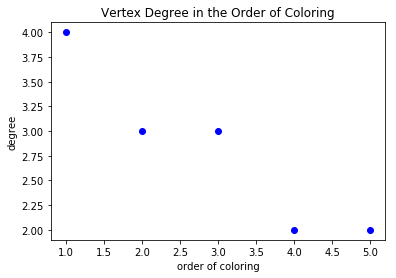

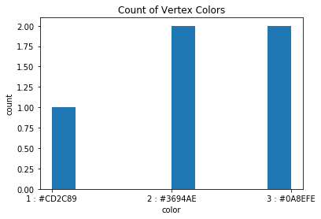

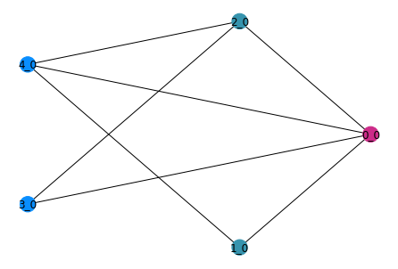

```
Maximum Clique: ['0_0', '2_0', '3_0']
Maximum Clique Size: 3
All cliques [['0_0', '2_0', '3_0'], ['0_0', '2_0', '4_0'], ['0_0', '1_0', '4_0']]
Num of Cliques: 3

Largest Last Vertex
-----------------------------------------------------------------------
-----------------------------------------------------------------------
OUTPUT:

Parameters:

C: 5
S: 10
K: 2
SectionSize: 5
SPLIT: BASIC
DIST: UNIFORM

Student Assignment Calculations:
T: 7
M: 10
-----------------------------------------------------------------------

vertexNo 3_0
original degree 3
degree when deleted 0
color hex: #BD6ADB number: 1
vertexNo 1_0
original degree 3
degree when deleted 0
color hex: #BD6ADB number: 1
vertexNo 2_0
original degree 3
degree when deleted 1
color hex: #EDE490 number: 2
vertexNo 4_0
original degree 2
degree when deleted 2
color hex: #0EF358 number: 3
vertexNo 0_0
original degree 3
degree when deleted 4
color hex: #D61A91 number: 4


Total number of colors used: 4
Rounded Average Degree: 3
Maximum Average Degree When Deleted: 4
```

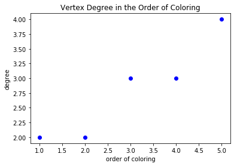

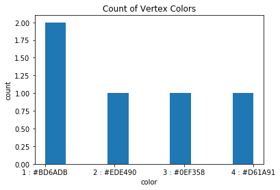

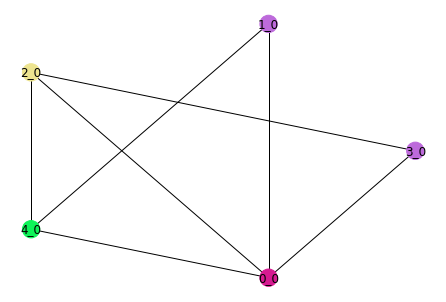

```
Maximum Clique: ['0_0', '2_0', '3_0']
Maximum Clique Size: 3
All cliques [['0_0', '2_0', '3_0'], ['0_0', '2_0', '4_0'], ['0_0', '1_0', '4_0']]
Num of Cliques: 3

Random Vertex
-----------------------------------------------------------------------
-----------------------------------------------------------------------
OUTPUT:

Parameters:

C: 5
S: 10
K: 2
SectionSize: 5
SPLIT: BASIC
DIST: UNIFORM

Student Assignment Calculations:
T: 7
M: 10
-----------------------------------------------------------------------

vertexNo 2_0
degree 3
color hex: #C554DF number: 1
vertexNo 1_0
degree 3
color hex: #C554DF number: 1
vertexNo 3_0
degree 3
color hex: #2E4D56 number: 2
vertexNo 4_0
degree 2
color hex: #2E4D56 number: 2
vertexNo 0_0
degree 3
color hex: #46F43D number: 3


Total number of colors used: 3
Rounded Average Degree: 3
```

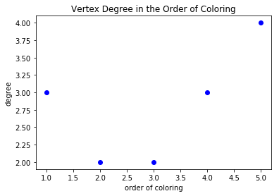

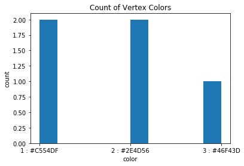

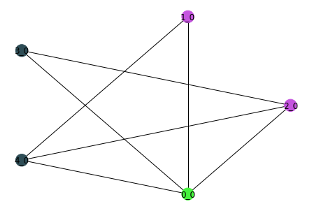

```
Maximum Clique: ['0_0', '2_0', '3_0']
Maximum Clique Size: 3
All cliques [['0_0', '2_0', '3_0'], ['0_0', '2_0', '4_0'], ['0_0', '1_0', '4_0']]
Num of Cliques: 3
Smallest Last Vertex Ordering Runtime: 6.580352783203125e-05
Largest Last Vertex Ordering Runtime: 6.580352783203125e-05
Random Vertex Ordering Runtime:  6.580352783203125e-05
Smallest Last Vertex Coloring Runtime: 5.507469177246094e-05
Largest Last Vertex Coloring Runtime: 5.507469177246094e-05
Random Vertex Coloring Runtime:  5.507469177246094e-05
```

```python
C, S, K, SectionSize, SPLIT, DIST, selected_courses = update_parameters("project_test1.txt")
C, S, K, SectionSize, SPLIT, DIST, M, T, E, P, adjacency_list = part1_return(C, S, K, SectionSize, SPLIT, DIST)
part2(C, S, K, SectionSize, SPLIT, DIST, M, T, E, P, adjacency_list)
```

```python
%%writefile project_test1.txt
5
14
3
5
BASIC
UNIFORM
```

```
Overwriting project_test1.txt
```

```
Suppress all outputs? Enter Y: Y

Smallest Last Vertex
-----------------------------------------------------------------------
-----------------------------------------------------------------------
OUTPUT:

Parameters:

C: 5
S: 14
K: 3
SectionSize: 5
SPLIT: BASIC
DIST: UNIFORM

Student Assignment Calculations:
T: 21
M: 42
-----------------------------------------------------------------------

vertexNo 4_0
original degree 2
degree when deleted 0
color hex: #CB88E9 number: 1
vertexNo 3_0
original degree 3
degree when deleted 1
color hex: #A6DCE3 number: 2
vertexNo 0_0
original degree 3
degree when deleted 2
color hex: #9E6D6E number: 3
vertexNo 1_0
original degree 3
degree when deleted 3
color hex: #5DE291 number: 4
vertexNo 2_0
original degree 3
degree when deleted 4
color hex: #6CC5E4 number: 5
vertexNo 2_1
original degree 4
degree when deleted 4
color hex: #6CC5E4 number: 5
vertexNo 2_2
original degree 57
degree when deleted 3
color hex: #A6DCE3 number: 2
vertexNo 0_1
original degree 2
degree when deleted 4
color hex: #9E6D6E number: 3


Total number of colors used: 5
Rounded Average Degree: 5
Maximum Average Degree When Deleted: 4
Terminal Clique ['4_0', '3_0', '0_0', '1_0', '2_0']
Terminal Clique Size: 5
```

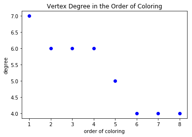

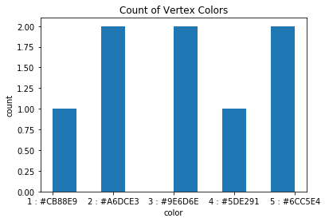

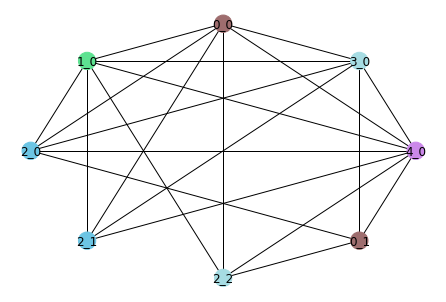

```
Largest Last Vertex
-----------------------------------------------------------------------
-----------------------------------------------------------------------
OUTPUT:

Parameters:

C: 5
S: 14
K: 3
SectionSize: 5
SPLIT: BASIC
DIST: UNIFORM

Student Assignment Calculations:
T: 21
M: 42
-----------------------------------------------------------------------

vertexNo 2_1
original degree 4
degree when deleted 0
color hex: #72231A number: 1
vertexNo 2_2
original degree 57
degree when deleted 0
color hex: #72231A number: 1
vertexNo 2_0
original degree 3
degree when deleted 0
color hex: #72231A number: 1
vertexNo 0_1
original degree 2
degree when deleted 2
color hex: #5CBC0C number: 2
vertexNo 3_0
original degree 3
degree when deleted 3
color hex: #95A1BF number: 3
vertexNo 0_0
original degree 3
degree when deleted 4
color hex: #5CBC0C number: 2
vertexNo 1_0
original degree 3
degree when deleted 5
color hex: #58EFEF number: 4
vertexNo 4_0
original degree 2
degree when deleted 7
color hex: #035D9E number: 5


Total number of colors used: 5
Rounded Average Degree: 5
Maximum Average Degree When Deleted: 7
```

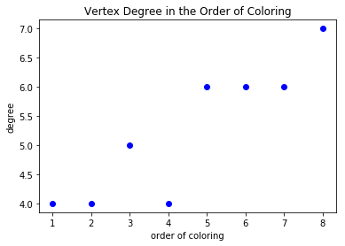

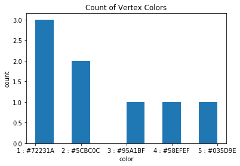

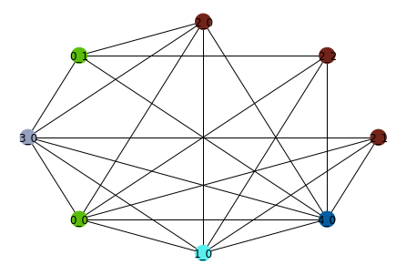

```
Random Vertex
-----------------------------------------------------------------------
-----------------------------------------------------------------------
OUTPUT:

Parameters:

C: 5
S: 14
K: 3
SectionSize: 5
SPLIT: BASIC
DIST: UNIFORM

Student Assignment Calculations:
T: 21
M: 42
-----------------------------------------------------------------------

vertexNo 0_0
degree 3
color hex: #29D287 number: 1
vertexNo 2_1
degree 4
color hex: #FDBD07 number: 2
vertexNo 2_0
degree 3
color hex: #FDBD07 number: 2
vertexNo 3_0
degree 3
color hex: #132D48 number: 3
vertexNo 0_1
degree 2
color hex: #29D287 number: 1
vertexNo 2_2
degree 57
color hex: #FDBD07 number: 2
vertexNo 1_0
degree 3
color hex: #D92B02 number: 4
vertexNo 4_0
degree 2
color hex: #237C81 number: 5


Total number of colors used: 5
Rounded Average Degree: 5
```

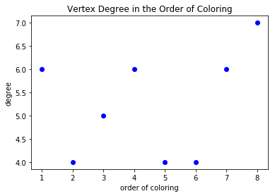

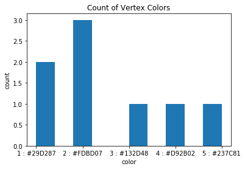

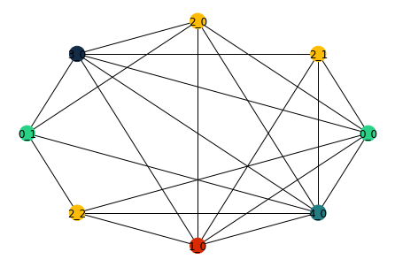

```
Smallest Last Vertex Ordering Runtime: 0.00012636184692382812
Largest Last Vertex Ordering Runtime: 0.00012636184692382812
Random Vertex Ordering Runtime:  0.00012636184692382812
Smallest Last Vertex Coloring Runtime: 8.392333984375e-05
Largest Last Vertex Coloring Runtime: 8.392333984375e-05
Random Vertex Coloring Runtime:  8.392333984375e-05
```

```python
C, S, K, SectionSize, SPLIT, DIST, selected_courses = update_parameters("project_test1.txt")
C, S, K, SectionSize, SPLIT, DIST, M, T, E, P, adjacency_list = part1_return(C, S, K, SectionSize, SPLIT, DIST)
part2(C, S, K, SectionSize, SPLIT, DIST, M, T, E, P, adjacency_list)
```

# Basic Tests: Different Distributions

Will distribution affect the way these graphs are colored and created?

```python
OUTPUT2_VERBOSE = False #Let's not print all of the vertices
OUTPUT2 = False #The graphs are meaningless with the amount of vertices so I won't plot them here
```

#### Uniform Distribution

```python
%%writefile project_test1.txt
50
100
20
30
BASIC
UNIFORM
```

```
Overwriting project_test1.txt
```

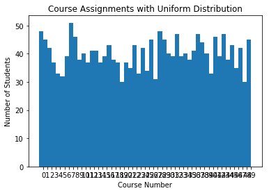

```
Suppress all outputs? Enter Y: Y

Smallest Last Vertex
-----------------------------------------------------------------------
-----------------------------------------------------------------------
OUTPUT:

Parameters:

C: 50
S: 100
K: 20
SectionSize: 30
SPLIT: BASIC
DIST: UNIFORM

Student Assignment Calculations:
T: 1274
M: 19000
-----------------------------------------------------------------------



Total number of colors used: 50
Rounded Average Degree: 50
Maximum Average Degree When Deleted: 49
Terminal Clique ['34_0', '4_0', '46_0', '32_0', '19_0', '39_0', '9_0', '31_0', '36_0', '15_0', '6_0', '28_0', '3_0', '2_0', '40_0', '43_0', '22_0', '23_0', '29_0', '48_0', '27_0', '42_0', '25_0', '20_0', '16_0', '45_0', '1_0', '41_0', '21_0', '24_0', '47_0', '7_0', '30_0', '44_0', '35_0', '12_0', '1…
Terminal Clique Size: 50
```

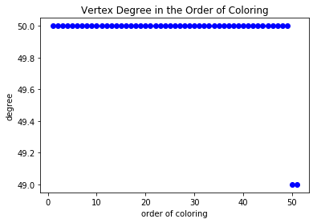

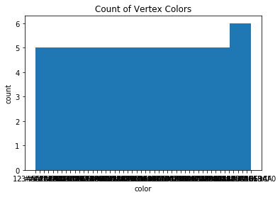

```
Largest Last Vertex
-----------------------------------------------------------------------
-----------------------------------------------------------------------
OUTPUT:

Parameters:

C: 50
S: 100
K: 20
SectionSize: 30
SPLIT: BASIC
DIST: UNIFORM

Student Assignment Calculations:
T: 1274
M: 19000
-----------------------------------------------------------------------



Total number of colors used: 50
Rounded Average Degree: 50
Maximum Average Degree When Deleted: 50
```

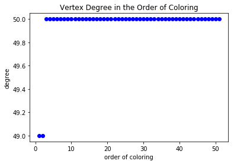

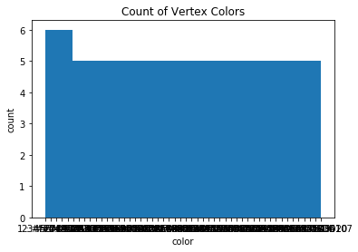

```
Random Vertex
-----------------------------------------------------------------------
-----------------------------------------------------------------------
OUTPUT:

Parameters:

C: 50
S: 100
K: 20
SectionSize: 30
SPLIT: BASIC
DIST: UNIFORM

Student Assignment Calculations:
T: 1274
M: 19000
-----------------------------------------------------------------------



Total number of colors used: 50
Rounded Average Degree: 50
```

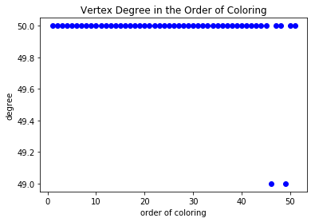

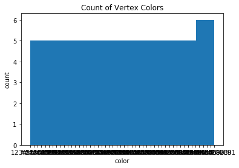

```
Smallest Last Vertex Ordering Runtime: 0.00037217140197753906
Largest Last Vertex Ordering Runtime: 0.00037217140197753906
Random Vertex Ordering Runtime:  0.00037217140197753906
Smallest Last Vertex Coloring Runtime: 0.002332925796508789
Largest Last Vertex Coloring Runtime: 0.002332925796508789
Random Vertex Coloring Runtime:  0.002332925796508789
```

```python
C, S, K, SectionSize, SPLIT, DIST, selected_courses = update_parameters("project_test1.txt")
selected_courses, course_assigments, course_enrollment = determine_courses(C, S, K, SectionSize, SPLIT, DIST)

labels, values = zip(*selected_courses)
indexes = np.arange(len(labels))
width = 1

plt.bar(indexes, values, width)
plt.xticks(indexes + width * 0.5, labels)
plt.xlabel("Course Number")
plt.ylabel("Number of Students")
plt.title("Course Assignments with Uniform Distribution")
plt.show()
C, S, K, SectionSize, SPLIT, DIST, M, T, E, P, adjacency_list = part1_return(C, S, K, SectionSize, SPLIT, DIST)
part2(C, S, K, SectionSize, SPLIT, DIST, M, T, E, P, adjacency_list)
```